# Segmentation avec CAH

```python
from sklearn.cluster import AgglomerativeClustering
from sklearn.metrics import silhouette_score, adjusted_rand_score

# methods = ["ward", "single", "average", "complete"]
# clusters = [[3, 5, 6, 8], [5, 7], [4, 6, 9], [4, 6, 9]]

# results_df = []
# for method, cluster in zip(methods, clusters):
#   print("#" *80)
#   print(f"Méthode: {method}")

#   for c in cluster:
#     print(f"{c} clusters")

#     cah = AgglomerativeClustering(n_clusters= c, linkage= method,
#           compute_full_tree= False).fit(X_samples)
#     sil_score = silhouette_score(X_samples, cah.labels_)
#     ari = adjusted_rand_score(cah.labels_, cah.fit_predict(X_samples))

#     results_df.append([method, c, sil_score, ari])
#   print("\n")
```

```python
# clusters_df = pd.DataFrame(results_df, columns= ["method", "clusters",
#                                                 "sil_score", "ari"])
```

```python
# clusters_df.to_csv("POLIST_16_CAH_scores.csv", index= False)
# files.download("POLIST_16_CAH_scores.csv")
```

```python
files.upload()

clusters_df = pd.read_csv("POLIST_16_CAH_scores.csv")
clusters_df.sort_values(by= "sil_score", ascending= False)
```

Upload widget is only available when the cell has been executed in the current browser session. Please rerun this cell to enable.

```
Saving POLIST_16_CAH_scores.csv to POLIST_16_CAH_scores.csv
```

|  | method | clusters | sil_score | ari |
| --- | --- | --- | --- | --- |
| 6 | average | 4 | 0.867032 | 1.0 |
| 9 | complete | 4 | 0.848932 | 1.0 |
| 7 | average | 6 | 0.755736 | 1.0 |
| 4 | single | 5 | 0.751937 | 1.0 |
| 5 | single | 7 | 0.751936 | 1.0 |
| 10 | complete | 6 | 0.702047 | 1.0 |
| 11 | complete | 9 | 0.700797 | 1.0 |
| 8 | average | 9 | 0.699110 | 1.0 |
| 1 | ward | 5 | 0.430242 | 1.0 |
| 0 | ward | 3 | 0.403181 | 1.0 |
| 2 | ward | 6 | 0.356622 | 1.0 |
| 3 | ward | 8 | 0.339446 | 1.0 |

Le silhouette score est le plus élevé (0.867) avec l'utilisation de la méthode "average" pour le linkage et 4 clusters.

Néanmoins, j'estime le nombre de clusters un peu faible. Je vais donc plutôt utilser le CAH avec 6 clusters et la méthode "average" qui obtient malgré tout un silouette score de 0.756.

```python
labels = pd.DataFrame(AgglomerativeClustering(n_clusters= 6, linkage= "average",
      compute_full_tree= False).fit_predict(X_samples), columns= ["labels"],
      index= X_samples.index).reset_index(drop= True)
```

Maintenant, je vais effectuer un PCA pour visualiser la répartition des clusters.

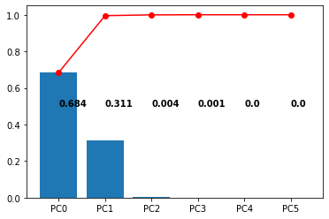

```python
from sklearn.decomposition import PCA

components = 6

pca = PCA(n_components= components)
pca.fit(X_samples)

X_pca = pd.DataFrame(pca.transform(X_samples))

expl_var_ratio = pca.explained_variance_ratio_
var_cumsum = expl_var_ratio.cumsum()

plt.bar(["PC" + str(x) for x in range(len(expl_var_ratio))], expl_var_ratio)
plt.plot(["PC" + str(x) for x in range(len(var_cumsum))], var_cumsum, "ro-")

for num, evr in enumerate(expl_var_ratio):
    plt.text(num, 0.5, str(np.round(evr, 3)), fontweight= "bold")

plt.show()
```

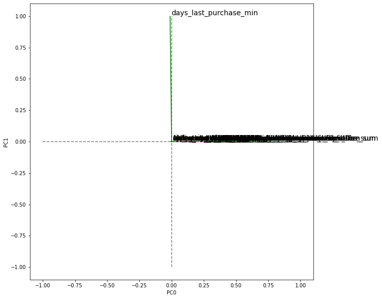

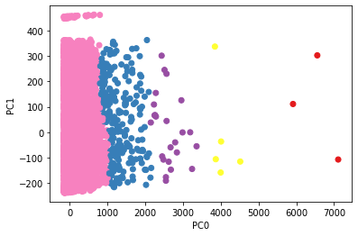

```python
fig = plt.figure(figsize=(10, 10))
plt.plot([-1, 1], [0, 0], color= "grey", ls="--")
plt.plot([0, 0], [-1, 1], color= "grey", ls="--")

for i, (x, y) in enumerate(zip(pca.components_.T[:, 0], pca.components_.T[:, 1])):
    plt.plot([0, x], [0, y], color= "g", ls= "-")
    plt.text(x + 0.01, y + 0.01, X.columns[i], fontsize= 14)

plt.xlabel("PC0")
plt.ylabel("PC1")

plt.show()

plt.scatter(X_pca.iloc[:, 0], X_pca.iloc[:, 1], c= labels["labels"], cmap= "Set1")

plt.xlabel("PC0")
plt.ylabel("PC1")

plt.show()
```

```python
X_df = raw_datas.iloc[samples, :].reset_index(drop= True)
```

```python
from sklearn.preprocessing import OneHotEncoder

X_cust = X_df.customer_state.to_numpy().reshape(-1, 1)
ohe = OneHotEncoder().fit(X_cust)

X_ohe = pd.DataFrame(ohe.transform(X_cust).toarray(), columns= ohe.get_feature_names_out(["customer_state__"]), index= X_df.index)
```

```python
X_dff = X_df.merge(X_ohe, left_index= True, right_index= True)
X_dff.drop("customer_state", axis= 1, inplace= True)
```

```python
segments_names = ["cluster_" + str(x) for x in np.sort(labels["labels"].unique())]
conditions = [labels["labels"] == x for x in np.sort(labels["labels"].unique())]

segments = segmentation(X_dff, conditions, segments_names)
segments
```

|  | segment_name | nb_clients | perc_clients | payment_mean_value | montant_CA | perc_CA | buyed_prod_mean | prod_price_mean | buyed_prod_nb | perc_buyed_prod_nb | perc_boleto_payment | perc_credit_card_payment | perc_debit_card_payment | perc_voucher_payment | best_cat_1 | perc_best_cat_1 | best_cat_2 | perc_best_cat_2 | best_cat_3 | perc_best_cat_3 | worst_cat_1 | perc_worst_cat_1 | worst_cat_2 | perc_worst_cat_2 | worst_cat_3 | perc_worst_cat_3 | mean_last_purchase_day | mean_frequency | mean_scores | … |
| --- | --- | --- | --- | --- | --- | --- | --- | --- | --- | --- | --- | --- | --- | --- | --- | --- | --- | --- | --- | --- | --- | --- | --- | --- | --- | --- | --- | --- | --- | --- |
| 0 | cluster_0 | 3 | 0.0 | 6694.36 | 20083.08 | 0.4 | 3.67 | 1824.08 | 11 | 0.0 | 100.0 | 0.0 | 0.0 | 0.0 | agro industry and commerce | 33.3 | art | 33.3 | fixed telephony | 33.3 | food | 0.0 | kitchen laptops and food preparers | 0.0 | kitchen dining laundry garden furniture | 0.0 | 261.7 | 1.0 | 2.3 | … |
| 1 | cluster_1 | 253 | 0.9 | 1465.12 | 370676.46 | 8.0 | 1.59 | 921.46 | 402 | 1.2 | 15.3 | 79.9 | 1.0 | 3.8 | health beauty | 11.5 | computers | 10.1 | watches gifts | 9.8 | agro industry and commerce | 0.0 | fashion childrens clothes | 0.0 | fashion male clothing | 0.0 | 277.9 | 1.1 | 4.0 | … |
| 2 | cluster_2 | 24 | 0.1 | 2788.31 | 66919.38 | 1.4 | 1.75 | 1593.32 | 42 | 0.1 | 25.9 | 74.1 | 0.0 | 0.0 | computers accessories | 14.8 | computers | 14.8 | watches gifts | 7.4 | food | 0.0 | fashion shoes | 0.0 | fashion sport | 0.0 | 215.8 | 1.1 | 4.3 | … |
| 3 | cluster_3 | 5 | 0.0 | 4214.38 | 21071.90 | 0.5 | 1.00 | 4214.38 | 5 | 0.0 | 0.0 | 83.3 | 16.7 | 0.0 | watches gifts | 20.0 | consoles games | 20.0 | baby | 20.0 | agro industry and commerce | 0.0 | kitchen dining laundry garden furniture | 0.0 | industry commerce and business | 0.0 | 173.2 | 1.0 | 4.8 | … |
| 4 | cluster_4 | 27558 | 99.0 | 150.26 | 4140976.71 | 89.6 | 1.17 | 128.43 | 32130 | 98.6 | 19.2 | 74.0 | 1.4 | 5.3 | bed bath table | 10.2 | health beauty | 8.8 | sports leisure | 7.7 | security and services | 0.0 | pc gamer | 0.0 | kitchen laptops and food preparers | 0.0 | 236.9 | 1.0 | 4.1 | … |
| 5 | cluster_5 | 6 | 0.0 | 185.96 | 1115.75 | 0.0 | 1.00 | 185.96 | 6 | 0.0 | 66.7 | 33.3 | 0.0 | 0.0 | construction tools safety | 16.7 | furniture decor | 16.7 | auto | 16.7 | agro industry and commerce | 0.0 | kitchen dining laundry garden furniture | 0.0 | industry commerce and business | 0.0 | 440.7 | 1.0 | 3.5 | … |